# House Sales in King County, USA

This R notebook will be exploring this dataset provided by Kaggle: https://www.kaggle.com/harlfoxem/housesalesprediction

Note: This project was worked on in the course of one afternoon. Because of this, I took a more exploratory approach in finding insights. I am sorry in advance if this excursion was a little haphazard. With that said, I hope you find tremendous value from it! Also, please offer suggestions if you have any!

# Let’s Get Started

We will build a simple regression model to predict the home sales price

## Initial Investigation

```r
house_data = read.csv(file.choose(), header=T)
head(house_data)
```

|  | id | date | price | bedrooms | bathrooms | sqft_living | sqft_lot | floors | waterfront | view | condition | grade | sqft_above | sqft_basement | yr_built | yr_renovated | zipcode | lat | long | sqft_living15 | sqft_lot15 |
| --- | --- | --- | --- | --- | --- | --- | --- | --- | --- | --- | --- | --- | --- | --- | --- | --- | --- | --- | --- | --- | --- |
| 1 | 7129300520 | 20141013T000000 | 221900 | 3 | 1.00 | 1180 | 5650 | 1 | 0 | 0 | 3 | 7 | 1180 | 0 | 1955 | 0 | 98178 | 47.5112 | -122.257 | 1340 | 5650 |
| 2 | 6414100192 | 20141209T000000 | 538000 | 3 | 2.25 | 2570 | 7242 | 2 | 0 | 0 | 3 | 7 | 2170 | 400 | 1951 | 1991 | 98125 | 47.7210 | -122.319 | 1690 | 7639 |
| 3 | 5631500400 | 20150225T000000 | 180000 | 2 | 1.00 | 770 | 10000 | 1 | 0 | 0 | 3 | 6 | 770 | 0 | 1933 | 0 | 98028 | 47.7379 | -122.233 | 2720 | 8062 |
| 4 | 2487200875 | 20141209T000000 | 604000 | 4 | 3.00 | 1960 | 5000 | 1 | 0 | 0 | 5 | 7 | 1050 | 910 | 1965 | 0 | 98136 | 47.5208 | -122.393 | 1360 | 5000 |
| 5 | 1954400510 | 20150218T000000 | 510000 | 3 | 2.00 | 1680 | 8080 | 1 | 0 | 0 | 3 | 8 | 1680 | 0 | 1987 | 0 | 98074 | 47.6168 | -122.045 | 1800 | 7503 |
| 6 | 7237550310 | 20140512T000000 | 1225000 | 4 | 4.50 | 5420 | 101930 | 1 | 0 | 0 | 3 | 11 | 3890 | 1530 | 2001 | 0 | 98053 | 47.6561 | -122.005 | 4760 | 101930 |

```r
#Let's check how many observations we have
dim(house_data)
```

```
[1] 21613    21
```

Let’s create a train and test set for our data ## Test and Train Set

```r
smp_size = floor(.7*nrow(house_data))
set.seed(123)
ind = sample(seq_len(nrow(house_data)),size=smp_size)
train_house_data = house_data[ind,]
test_house_data= house_data[-ind,]
dim(train_house_data)
```

```
[1] 15129    21
```

```r
dim(test_house_data)
```

```
[1] 6484   21
```

We will do a summary to find some descriptive statistics on each of the explanatory variables within our training set

## Descriptive Statistics

```r
attach(train_house_data)
summary(train_house_data)
```

```
       id                         date           price            bedrooms        bathrooms      sqft_living       sqft_lot           floors        waterfront
 Min.   :1.000e+06   20140708T000000:   94   Min.   :  75000   Min.   : 0.000   Min.   :0.000   Min.   :  370   Min.   :    520   Min.   :1.000   Min.   :0.000000
 1st Qu.:2.123e+09   20140625T000000:   93   1st Qu.: 323500   1st Qu.: 3.000   1st Qu.:1.500   1st Qu.: 1420   1st Qu.:   5091   1st Qu.:1.000   1st Qu.:0.000000
 Median :3.903e+09   20140623T000000:   92   Median : 450000   Median : 3.000   Median :2.250   Median : 1910   Median :   7633   Median :1.500   Median :0.000000
 Mean   :4.574e+09   20150422T000000:   90   Mean   : 540145   Mean   : 3.368   Mean   :2.111   Mean   : 2078   Mean   :  15410   Mean   :1.492   Mean   :0.007733
 3rd Qu.:7.304e+09   20140825T000000:   88   3rd Qu.: 640000   3rd Qu.: 4.000   3rd Qu.:2.500   3rd Qu.: 2540   3rd Qu.:  10800   3rd Qu.:2.000   3rd Qu.:0.000000
 Max.   :9.842e+09   20150325T000000:   88   Max.   :7700000   Max.   :33.000   Max.   :8.000   Max.   :12050   Max.   :1164794   Max.   :3.500   Max.   :1.000000
                     (Other)        :14584
      view          condition         grade          sqft_above   sqft_basement       yr_built     yr_renovated        zipcode           lat             long
 Min.   :0.0000   Min.   :1.000   Min.   : 3.000   Min.   : 370   Min.   :   0.0   Min.   :1900   Min.   :   0.00   Min.   :98001   Min.   :47.16   Min.   :-122.5
 1st Qu.:0.0000   1st Qu.:3.000   1st Qu.: 7.000   1st Qu.:1190   1st Qu.:   0.0   1st Qu.:1951   1st Qu.:   0.00   1st Qu.:98033   1st Qu.:47.47   1st Qu.:-122.3
 Median :0.0000   Median :3.000   Median : 7.000   Median :1552   Median :   0.0   Median :1975   Median :   0.00   Median :98065   Median :47.57   Median :-122.2
 Mean   :0.2371   Mean   :3.407   Mean   : 7.653   Mean   :1787   Mean   : 291.7   Mean   :1971   Mean   :  84.56   Mean   :98078   Mean   :47.56   Mean   :-122.2
 3rd Qu.:0.0000   3rd Qu.:4.000   3rd Qu.: 8.000   3rd Qu.:2200   3rd Qu.: 560.0   3rd Qu.:1997   3rd Qu.:   0.00   3rd Qu.:98118   3rd Qu.:47.68   3rd Qu.:-122.1
 Max.   :4.0000   Max.   :5.000   Max.   :13.000   Max.   :8860   Max.   :4820.0   Max.   :2015   Max.   :2015.00   Max.   :98199   Max.   :47.78   Max.   :-121.3

 sqft_living15    sqft_lot15
 Min.   : 460   Min.   :   651
 1st Qu.:1480   1st Qu.:  5108
 Median :1840   Median :  7644
 Mean   :1984   Mean   : 12922
 3rd Qu.:2360   3rd Qu.: 10125
 Max.   :6210   Max.   :858132
```

Also, there are lots of variables that explain the same behavior (i.e. location). We may remove these variables later on in the analysis because of multicollinearity.

## Histograms

```r
par(mfrow=c(4,6))
hist(price)
hist(bedrooms)
```

```r
hist(bathrooms)
hist(sqft_living)
```

```r
hist(sqft_lot)
hist(floors)
```

```r
hist(waterfront)
hist(view)
```

```r
hist(condition)
hist(grade)
```

```r
hist(sqft_above)
hist(sqft_basement)
```

```r
hist(yr_built)
hist(yr_renovated)
```

```r
hist(zipcode)
hist(lat)
```

```r
hist(long)
hist(sqft_living15)
```

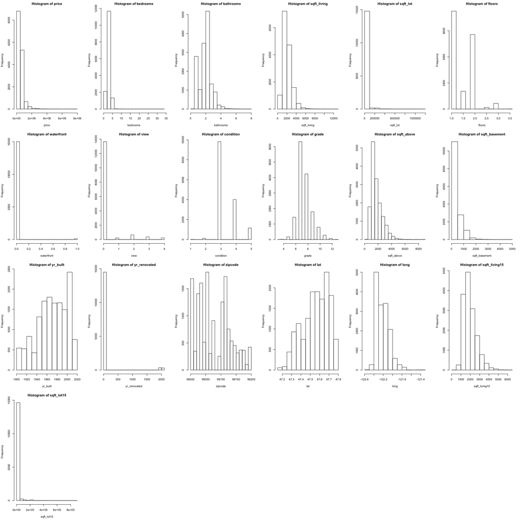

```r
hist(sqft_lot15)
```

From these histograms, we notice that a lot of our variables are incredibly right skewed. This is problematic. From the looks of it, there are many variables in which they have a high a frequency of an empty value (i.e. waterfront, view). This is why they are incredibly skewed. Because of this, we will remove waterfront, view, yr_renovated from all regression models.

### Transformations and New Histograms

Let’s apply a natural log transformation onto bedroom, and all of the sqft variables

```r
ln_bedroom = log(bedrooms+1)
ln_sqft_basement = log(sqft_basement+1)
ln_sqft_living = log(sqft_living)
ln_sqft_above = log(sqft_above)
ln_sqft15_living = log(sqft_living15)
ln_sqft15_lot = log(sqft_lot15)
ln_price = log(price)
par(mfrow=c(2,4))
hist(ln_bedroom)
hist(ln_sqft_basement)
```

```r
hist(ln_sqft_living)
hist(ln_sqft_above)
```

```r
hist(ln_sqft15_living)
hist(ln_sqft15_lot)
```

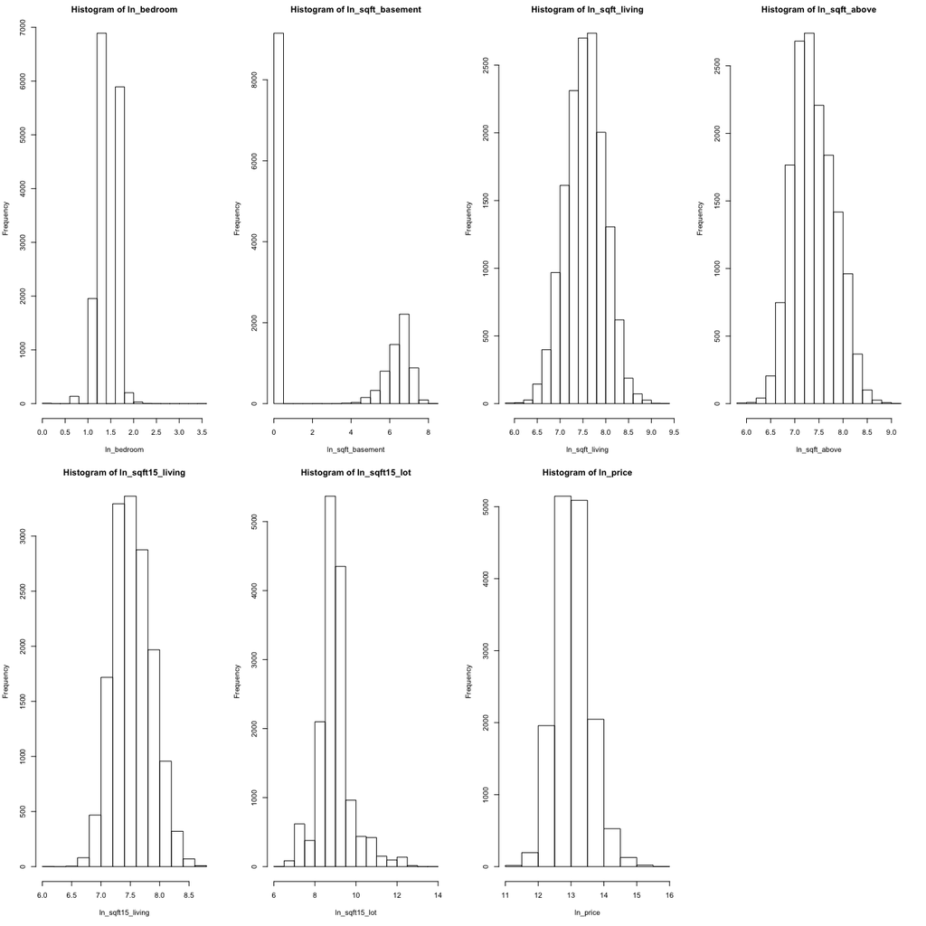

```r
hist(ln_price)
```

## Comments on Categorical Variables

We will treat grade, floors, and condition as categorical variables

```r
cat_grade = factor(grade)
cat_cond = factor(condition)
cat_floors = factor(floors)
```

## Scatterplots

We will now build a scatterplot matrix to see if any of the explanatory variables need a square term.

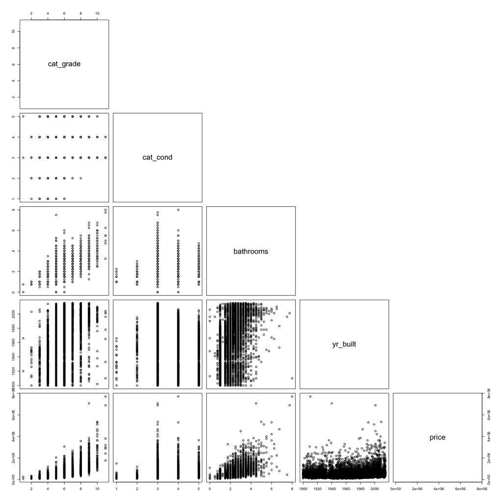

```r
vars1 = data.frame(cat_grade,cat_cond,bathrooms,yr_built,price)
vars2  = data.frame(ln_sqft_living,ln_sqft15_lot,cat_floors,ln_sqft_above,price)
vars3 =  data.frame(zipcode,lat,long,ln_sqft15_living,ln_sqft15_lot,ln_bedroom,ln_sqft_basement,price)
pairs(vars1, upper.panel = NULL)
```

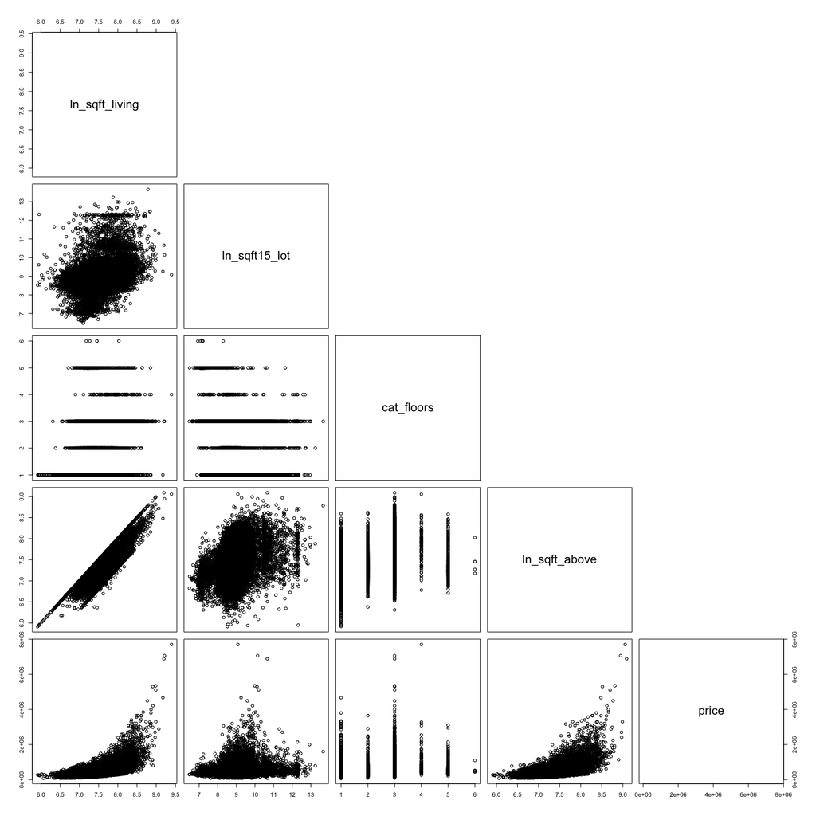

```r
pairs(vars2, upper.panel = NULL)
```

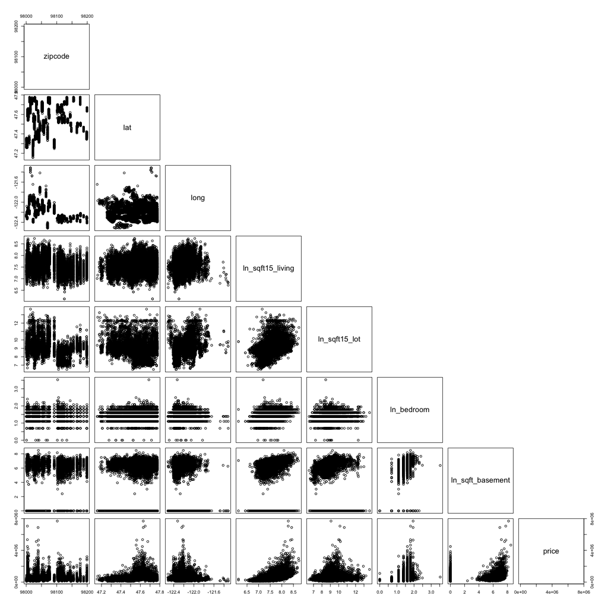

```r
pairs(vars3, upper.panel = NULL)
```

From these various scatterplot matrices we see that ln_sqft_living, ln_sqft_basement may need a square term

```r
basementSq = ln_sqft_basement ** 2
sqft_livingSq = ln_sqft_living ** 2
```

Let us start by creating a simple regression model.

## Regression

For starters, we will build a model using our price variable. In our final model, if we notice any heteroscedasticity then we will use the natural log of price variable for our Y

```r
m1  = lm(price ~ cat_grade+cat_cond+cat_floors+bathrooms+ln_sqft_living+ln_sqft15_lot+ln_sqft_above+yr_built+zipcode+lat+long+ln_sqft15_living+ln_sqft15_lot+ln_bedroom+ln_sqft_basement+basementSq+sqft_livingSq)
summary(m1)
```

```
Call:
lm(formula = price ~ cat_grade + cat_cond + cat_floors + bathrooms +
    ln_sqft_living + ln_sqft15_lot + ln_sqft_above + yr_built +
    zipcode + lat + long + ln_sqft15_living + ln_sqft15_lot +
    ln_bedroom + ln_sqft_basement + basementSq + sqft_livingSq)

Residuals:
     Min       1Q   Median       3Q      Max
-1634591   -95962   -10949    71991  4450946

Coefficients:
                   Estimate Std. Error t value Pr(>|t|)
(Intercept)       1.958e+07  3.732e+06   5.247 1.56e-07 ***
cat_grade4       -1.767e+05  1.537e+05  -1.150  0.25025
cat_grade5       -2.845e+04  1.468e+05  -0.194  0.84637
cat_grade6        3.839e+04  1.462e+05   0.262  0.79297
cat_grade7        1.070e+05  1.464e+05   0.731  0.46483
cat_grade8        1.714e+05  1.465e+05   1.170  0.24209
cat_grade9        2.831e+05  1.466e+05   1.930  0.05358 .
cat_grade10       4.366e+05  1.467e+05   2.975  0.00293 **
cat_grade11       7.141e+05  1.471e+05   4.854 1.22e-06 ***
cat_grade12       1.194e+06  1.488e+05   8.023 1.11e-15 ***
cat_grade13       2.379e+06  1.645e+05  14.462  < 2e-16 ***
cat_cond2         1.641e+03  4.791e+04   0.034  0.97268
cat_cond3         2.525e+04  4.450e+04   0.567  0.57048
cat_cond4         5.819e+04  4.452e+04   1.307  0.19115
cat_cond5         1.010e+05  4.481e+04   2.253  0.02428 *
cat_floors1.5     7.897e+03  6.796e+03   1.162  0.24530
cat_floors2       4.111e+00  5.728e+03   0.001  0.99943
cat_floors2.5     8.389e+04  1.988e+04   4.220 2.45e-05 ***
cat_floors3       5.869e+04  1.229e+04   4.776 1.81e-06 ***
cat_floors3.5     1.225e+05  9.255e+04   1.323  0.18576
bathrooms         5.278e+04  4.038e+03  13.071  < 2e-16 ***
ln_sqft_living   -3.850e+06  1.402e+05 -27.464  < 2e-16 ***
ln_sqft15_lot    -1.897e+04  2.677e+03  -7.086 1.45e-12 ***
ln_sqft_above     3.807e+05  2.931e+04  12.990  < 2e-16 ***
yr_built         -2.431e+03  9.339e+01 -26.027  < 2e-16 ***
zipcode          -5.468e+02  4.049e+01 -13.505  < 2e-16 ***
lat               5.510e+05  1.324e+04  41.629  < 2e-16 ***
long             -2.000e+05  1.640e+04 -12.189  < 2e-16 ***
ln_sqft15_living  1.102e+05  8.635e+03  12.765  < 2e-16 ***
ln_bedroom       -8.674e+04  1.084e+04  -8.004 1.29e-15 ***
ln_sqft_basement -3.395e+04  6.907e+03  -4.915 8.96e-07 ***
basementSq        9.227e+03  1.252e+03   7.368 1.82e-13 ***
sqft_livingSq     2.459e+05  9.957e+03  24.694  < 2e-16 ***
---
Signif. codes:  0 ‘***’ 0.001 ‘**’ 0.01 ‘*’ 0.05 ‘.’ 0.1 ‘ ’ 1

Residual standard error: 205900 on 15096 degrees of freedom
Multiple R-squared:  0.6943,    Adjusted R-squared:  0.6937
F-statistic:  1072 on 32 and 15096 DF,  p-value: < 2.2e-16
```

So, from the looks of it we have a decent model. The F p-value=2.2e-16 < alpha=.05 which means that this model is very significant. Also the R2 value=0.6943 and R2a=0.6937 difference is very small, which means we are not taking a penalty hit for the extra variables included in this model. Let’s build another model in which we will do backwards selection (or backwards regression). We also notice that the square terms for basement and sqft_living are significant since their t p-values<alpha=.05.

We will now create model 2 where we will do stepwise regression. ###Stepwise Regression

```r
m1_0 = lm(price ~ 1)
step(m1_0, scope=list(lower=m1_0, upper=m1, direction="both"))
```

```
Start:  AIC=388113.2
price ~ 1

                   Df  Sum of Sq        RSS    AIC
+ cat_grade        10 1.0847e+15 1.0092e+15 377091
+ sqft_livingSq     1 8.1773e+14 1.2762e+15 380624
+ ln_sqft_living    1 7.8133e+14 1.3126e+15 381049
+ ln_sqft_above     1 6.1829e+14 1.4757e+15 382821
+ ln_sqft15_living  1 6.1620e+14 1.4777e+15 382842
+ bathrooms         1 5.8581e+14 1.5081e+15 383150
+ ln_bedroom        1 1.9531e+14 1.8986e+15 386634
+ lat               1 1.8609e+14 1.9079e+15 386707
+ cat_floors        5 1.6667e+14 1.9273e+15 386868
+ basementSq        1 1.1209e+14 1.9819e+15 387283
+ ln_sqft_basement  1 8.8724e+13 2.0052e+15 387460
+ ln_sqft15_lot     1 4.8900e+13 2.0450e+15 387758
+ cat_cond          4 1.3633e+13 2.0803e+15 388022
+ yr_built          1 9.4932e+12 2.0845e+15 388046
+ zipcode           1 7.3542e+12 2.0866e+15 388062
+ long              1 1.2730e+12 2.0927e+15 388106
<none>                           2.0939e+15 388113

Step:  AIC=377091.1
price ~ cat_grade

                   Df  Sum of Sq        RSS    AIC
+ lat               1 1.1325e+14 8.9598e+14 375292
+ yr_built          1 9.8933e+13 9.1030e+14 375532
+ sqft_livingSq     1 8.6078e+13 9.2315e+14 375744
+ ln_sqft_living    1 7.9702e+13 9.2953e+14 375849
+ basementSq        1 6.7022e+13 9.4221e+14 376053
+ ln_sqft_basement  1 5.9877e+13 9.4936e+14 376168
+ cat_cond          4 3.6454e+13 9.7278e+14 376543
+ ln_sqft15_living  1 3.1564e+13 9.7767e+14 376612
+ bathrooms         1 2.9888e+13 9.7934e+14 376638
+ long              1 2.4877e+13 9.8436e+14 376716
+ cat_floors        5 2.4423e+13 9.8481e+14 376730
+ ln_sqft_above     1 1.4584e+13 9.9465e+14 376873
+ ln_bedroom        1 1.4375e+13 9.9486e+14 376876
+ zipcode           1 7.2627e+12 1.0020e+15 376984
```

[output cut: 353 more lines]

```
Call:
lm(formula = price ~ cat_grade + lat + sqft_livingSq + yr_built +
    ln_sqft_living + bathrooms + cat_cond + ln_sqft15_living +
    long + zipcode + ln_sqft15_lot + ln_bedroom + cat_floors +
    ln_sqft_basement + ln_sqft_above + basementSq)

Coefficients:
     (Intercept)        cat_grade4        cat_grade5        cat_grade6        cat_grade7        cat_grade8        cat_grade9       cat_grade10       cat_grade11
       1.958e+07        -1.767e+05        -2.845e+04         3.839e+04         1.070e+05         1.714e+05         2.831e+05         4.366e+05         7.141e+05
     cat_grade12       cat_grade13               lat     sqft_livingSq          yr_built    ln_sqft_living         bathrooms         cat_cond2         cat_cond3
       1.194e+06         2.379e+06         5.510e+05         2.459e+05        -2.431e+03        -3.850e+06         5.278e+04         1.641e+03         2.525e+04
       cat_cond4         cat_cond5  ln_sqft15_living              long           zipcode     ln_sqft15_lot        ln_bedroom     cat_floors1.5       cat_floors2
       5.819e+04         1.010e+05         1.102e+05        -2.000e+05        -5.468e+02        -1.897e+04        -8.674e+04         7.897e+03         4.111e+00
   cat_floors2.5       cat_floors3     cat_floors3.5  ln_sqft_basement     ln_sqft_above        basementSq
       8.389e+04         5.869e+04         1.225e+05        -3.395e+04         3.807e+05         9.227e+03
```

We have now found model 2. Interestingly enough, the model 2 is exactly like m1. Let’s do backwards regression on the model 1. We will discard the stepwise regression model ###Model 2

```r
m2 = lm(price ~ cat_grade + lat + sqft_livingSq + yr_built +
    ln_sqft_living + bathrooms + cat_cond + ln_sqft15_living +
    long + zipcode + ln_sqft15_lot + ln_bedroom + cat_floors +
    ln_sqft_basement + ln_sqft_above + basementSq)
summary(m2)
```

```
Call:
lm(formula = price ~ cat_grade + lat + sqft_livingSq + yr_built +
    ln_sqft_living + bathrooms + cat_cond + ln_sqft15_living +
    long + zipcode + ln_sqft15_lot + ln_bedroom + cat_floors +
    ln_sqft_basement + ln_sqft_above + basementSq)

Residuals:
     Min       1Q   Median       3Q      Max
-1634591   -95962   -10949    71991  4450946

Coefficients:
                   Estimate Std. Error t value Pr(>|t|)
(Intercept)       1.958e+07  3.732e+06   5.247 1.56e-07 ***
cat_grade4       -1.767e+05  1.537e+05  -1.150  0.25025
cat_grade5       -2.845e+04  1.468e+05  -0.194  0.84637
cat_grade6        3.839e+04  1.462e+05   0.262  0.79297
cat_grade7        1.070e+05  1.464e+05   0.731  0.46483
cat_grade8        1.714e+05  1.465e+05   1.170  0.24209
cat_grade9        2.831e+05  1.466e+05   1.930  0.05358 .
cat_grade10       4.366e+05  1.467e+05   2.975  0.00293 **
cat_grade11       7.141e+05  1.471e+05   4.854 1.22e-06 ***
cat_grade12       1.194e+06  1.488e+05   8.023 1.11e-15 ***
cat_grade13       2.379e+06  1.645e+05  14.462  < 2e-16 ***
lat               5.510e+05  1.324e+04  41.629  < 2e-16 ***
sqft_livingSq     2.459e+05  9.957e+03  24.694  < 2e-16 ***
yr_built         -2.431e+03  9.339e+01 -26.027  < 2e-16 ***
ln_sqft_living   -3.850e+06  1.402e+05 -27.464  < 2e-16 ***
bathrooms         5.278e+04  4.038e+03  13.071  < 2e-16 ***
cat_cond2         1.641e+03  4.791e+04   0.034  0.97268
cat_cond3         2.525e+04  4.450e+04   0.567  0.57048
cat_cond4         5.819e+04  4.452e+04   1.307  0.19115
cat_cond5         1.010e+05  4.481e+04   2.253  0.02428 *
ln_sqft15_living  1.102e+05  8.635e+03  12.765  < 2e-16 ***
long             -2.000e+05  1.640e+04 -12.189  < 2e-16 ***
zipcode          -5.468e+02  4.049e+01 -13.505  < 2e-16 ***
ln_sqft15_lot    -1.897e+04  2.677e+03  -7.086 1.45e-12 ***
ln_bedroom       -8.674e+04  1.084e+04  -8.004 1.29e-15 ***
cat_floors1.5     7.897e+03  6.796e+03   1.162  0.24530
cat_floors2       4.111e+00  5.728e+03   0.001  0.99943
cat_floors2.5     8.389e+04  1.988e+04   4.220 2.45e-05 ***
cat_floors3       5.869e+04  1.229e+04   4.776 1.81e-06 ***
cat_floors3.5     1.225e+05  9.255e+04   1.323  0.18576
ln_sqft_basement -3.395e+04  6.907e+03  -4.915 8.96e-07 ***
ln_sqft_above     3.807e+05  2.931e+04  12.990  < 2e-16 ***
basementSq        9.227e+03  1.252e+03   7.368 1.82e-13 ***
---
Signif. codes:  0 ‘***’ 0.001 ‘**’ 0.01 ‘*’ 0.05 ‘.’ 0.1 ‘ ’ 1

Residual standard error: 205900 on 15096 degrees of freedom
Multiple R-squared:  0.6943,    Adjusted R-squared:  0.6937
F-statistic:  1072 on 32 and 15096 DF,  p-value: < 2.2e-16
```

### Backwards Regression

```r
step(m1,data=train_house_data,direction="backward")
```

```
Start:  AIC=370245.3
price ~ cat_grade + cat_cond + cat_floors + bathrooms + ln_sqft_living +
    ln_sqft15_lot + ln_sqft_above + yr_built + zipcode + lat +
    long + ln_sqft15_living + ln_sqft15_lot + ln_bedroom + ln_sqft_basement +
    basementSq + sqft_livingSq

                   Df  Sum of Sq        RSS    AIC
<none>                           6.4005e+14 370245
- ln_sqft_basement  1 1.0244e+12 6.4107e+14 370267
- cat_floors        5 2.0203e+12 6.4207e+14 370283
- ln_sqft15_lot     1 2.1286e+12 6.4217e+14 370293
- basementSq        1 2.3018e+12 6.4235e+14 370298
- ln_bedroom        1 2.7164e+12 6.4276e+14 370307
- cat_cond          4 6.4596e+12 6.4650e+14 370389
- long              1 6.2997e+12 6.4634e+14 370391
- ln_sqft15_living  1 6.9089e+12 6.4695e+14 370406
- ln_sqft_above     1 7.1541e+12 6.4720e+14 370411
- bathrooms         1 7.2440e+12 6.4729e+14 370414
- zipcode           1 7.7324e+12 6.4778e+14 370425
- sqft_livingSq     1 2.5855e+13 6.6590e+14 370842
- yr_built          1 2.8720e+13 6.6877e+14 370907
- ln_sqft_living    1 3.1981e+13 6.7203e+14 370981
- lat               1 7.3474e+13 7.1352e+14 371887
- cat_grade        10 1.2558e+14 7.6563e+14 372936

Call:
lm(formula = price ~ cat_grade + cat_cond + cat_floors + bathrooms +
    ln_sqft_living + ln_sqft15_lot + ln_sqft_above + yr_built +
    zipcode + lat + long + ln_sqft15_living + ln_sqft15_lot +
    ln_bedroom + ln_sqft_basement + basementSq + sqft_livingSq)

Coefficients:
     (Intercept)        cat_grade4        cat_grade5        cat_grade6        cat_grade7        cat_grade8        cat_grade9       cat_grade10       cat_grade11
       1.958e+07        -1.767e+05        -2.845e+04         3.839e+04         1.070e+05         1.714e+05         2.831e+05         4.366e+05         7.141e+05
     cat_grade12       cat_grade13         cat_cond2         cat_cond3         cat_cond4         cat_cond5     cat_floors1.5       cat_floors2     cat_floors2.5
       1.194e+06         2.379e+06         1.641e+03         2.525e+04         5.819e+04         1.010e+05         7.897e+03         4.111e+00         8.389e+04
     cat_floors3     cat_floors3.5         bathrooms    ln_sqft_living     ln_sqft15_lot     ln_sqft_above          yr_built           zipcode               lat
       5.869e+04         1.225e+05         5.278e+04        -3.850e+06        -1.897e+04         3.807e+05        -2.431e+03        -5.468e+02         5.510e+05
            long  ln_sqft15_living        ln_bedroom  ln_sqft_basement        basementSq     sqft_livingSq
      -2.000e+05         1.102e+05        -8.674e+04        -3.395e+04         9.227e+03         2.459e+05
```

Once again, backwards regression picks the same model. This makes sense because in model 1, most of the t p-values were very significant in which they were less than an alpha= .05 or .01

Let’s compute an F partial test on our categorical variables to prove our assumption (that these groups add a significant effect on predicting the price of a home)

### Partial F test

```r
m1_floor =lm(price ~ cat_grade + cat_cond + bathrooms +
    ln_sqft_living + ln_sqft15_lot + ln_sqft_above + yr_built +
    zipcode + lat + long + ln_sqft15_living + ln_sqft15_lot +
    ln_bedroom + ln_sqft_basement + basementSq + sqft_livingSq)
m1_grade =lm(price ~  cat_cond + cat_floors + bathrooms +
    ln_sqft_living + ln_sqft15_lot + ln_sqft_above + yr_built +
    zipcode + lat + long + ln_sqft15_living + ln_sqft15_lot +
    ln_bedroom + ln_sqft_basement + basementSq + sqft_livingSq)
m1_cond =lm(price ~ cat_grade + cat_floors + bathrooms +
    ln_sqft_living + ln_sqft15_lot + ln_sqft_above + yr_built +
    zipcode + lat + long + ln_sqft15_living + ln_sqft15_lot +
    ln_bedroom + ln_sqft_basement + basementSq + sqft_livingSq)
anova(m1, m1_floor)
```

```
Analysis of Variance Table

Model 1: price ~ cat_grade + cat_cond + cat_floors + bathrooms + ln_sqft_living +
    ln_sqft15_lot + ln_sqft_above + yr_built + zipcode + lat +
    long + ln_sqft15_living + ln_sqft15_lot + ln_bedroom + ln_sqft_basement +
    basementSq + sqft_livingSq
Model 2: price ~ cat_grade + cat_cond + bathrooms + ln_sqft_living + ln_sqft15_lot +
    ln_sqft_above + yr_built + zipcode + lat + long + ln_sqft15_living +
    ln_sqft15_lot + ln_bedroom + ln_sqft_basement + basementSq +
    sqft_livingSq
  Res.Df        RSS Df   Sum of Sq      F    Pr(>F)
1  15096 6.4005e+14
2  15101 6.4207e+14 -5 -2.0203e+12 9.5301 4.327e-09 ***
---
Signif. codes:  0 ‘***’ 0.001 ‘**’ 0.01 ‘*’ 0.05 ‘.’ 0.1 ‘ ’ 1
```

```r
anova(m1, m1_cond)
```

```
Analysis of Variance Table

Model 1: price ~ cat_grade + cat_cond + cat_floors + bathrooms + ln_sqft_living +
    ln_sqft15_lot + ln_sqft_above + yr_built + zipcode + lat +
    long + ln_sqft15_living + ln_sqft15_lot + ln_bedroom + ln_sqft_basement +
    basementSq + sqft_livingSq
Model 2: price ~ cat_grade + cat_floors + bathrooms + ln_sqft_living +
    ln_sqft15_lot + ln_sqft_above + yr_built + zipcode + lat +
    long + ln_sqft15_living + ln_sqft15_lot + ln_bedroom + ln_sqft_basement +
    basementSq + sqft_livingSq
  Res.Df        RSS Df   Sum of Sq      F    Pr(>F)
1  15096 6.4005e+14
2  15100 6.4650e+14 -4 -6.4596e+12 38.089 < 2.2e-16 ***
---
Signif. codes:  0 ‘***’ 0.001 ‘**’ 0.01 ‘*’ 0.05 ‘.’ 0.1 ‘ ’ 1
```

```r
anova(m1, m1_grade)
```

```
Analysis of Variance Table

Model 1: price ~ cat_grade + cat_cond + cat_floors + bathrooms + ln_sqft_living +
    ln_sqft15_lot + ln_sqft_above + yr_built + zipcode + lat +
    long + ln_sqft15_living + ln_sqft15_lot + ln_bedroom + ln_sqft_basement +
    basementSq + sqft_livingSq
Model 2: price ~ cat_cond + cat_floors + bathrooms + ln_sqft_living +
    ln_sqft15_lot + ln_sqft_above + yr_built + zipcode + lat +
    long + ln_sqft15_living + ln_sqft15_lot + ln_bedroom + ln_sqft_basement +
    basementSq + sqft_livingSq
  Res.Df        RSS  Df   Sum of Sq      F    Pr(>F)
1  15096 6.4005e+14
2  15106 7.6563e+14 -10 -1.2558e+14 296.19 < 2.2e-16 ***
---
Signif. codes:  0 ‘***’ 0.001 ‘**’ 0.01 ‘*’ 0.05 ‘.’ 0.1 ‘ ’ 1
```

From all of these outputs, we see that the F p-value < alpha=.05 or .01. Because of this, the categorical variables are indeed highly significant.

Let’s see if we can remove any outlier and leverage points.

### Outliers, Leverage Points, Cook’s Distance

First let’s find the outliers. To do this we will find any standard residual errors that exceed the cutoff of the absolute value of 2.

```r
rsta = rstandard(m1)
temp_data_out = subset(train_house_data, (rsta>=2 & rsta<=-2))
temp_data_out
```

| id | date | price | bedrooms | bathrooms | sqft_living | sqft_lot | floors | waterfront | view | condition | grade | sqft_above | sqft_basement | yr_built | yr_renovated | zipcode | lat | long | sqft_living15 | sqft_lot15 |
| --- | --- | --- | --- | --- | --- | --- | --- | --- | --- | --- | --- | --- | --- | --- | --- | --- | --- | --- | --- | --- |

Cutoff: 3(k+1)/n

Cutoff: 3(33)/15129

Cutoff: 0.006543724

```r
dim(train_house_data)
```

```
[1] 15129    21
```

```r
cutoff = 3*(33)/15129
lev = hatvalues(m1)
temp_data = subset(train_house_data, (lev>cutoff))
nrow(temp_data)
```

```
[1] 543
```

```r
removed_train = which((lev>cutoff))
```

We have found 543 observations that exceed the cutoff. These are leverage points and we will remove it from the training data set. We will create a new model 2 from this

We will need to create a list to remove the points. We will create a function to do so.

```r
removal <- function(x){
  vector = c()
  for (i in 1:length(x)){
    vector[i] <- x[i]
  }
  return(vector)
}
lev_points = removal(removed_train)
```

### Model 2

```r
m2  = lm(price ~ cat_grade+cat_cond+cat_floors+bathrooms+ln_sqft_living+ln_sqft15_lot+ln_sqft_above+yr_built+zipcode+lat+long+ln_sqft15_living+ln_sqft15_lot+ln_bedroom+ln_sqft_basement+basementSq+sqft_livingSq, subset=-lev_points)
summary(m2)
```

```
Call:
lm(formula = price ~ cat_grade + cat_cond + cat_floors + bathrooms +
    ln_sqft_living + ln_sqft15_lot + ln_sqft_above + yr_built +
    zipcode + lat + long + ln_sqft15_living + ln_sqft15_lot +
    ln_bedroom + ln_sqft_basement + basementSq + sqft_livingSq,
    subset = -lev_points)

Residuals:
     Min       1Q   Median       3Q      Max
-1013645   -93434   -11609    68571  2219533

Coefficients:
                   Estimate Std. Error t value Pr(>|t|)
(Intercept)       1.360e+07  3.487e+06   3.900 9.64e-05 ***
cat_grade6        4.061e+04  6.655e+04   0.610  0.54172
cat_grade7        1.061e+05  6.662e+04   1.592  0.11143
cat_grade8        1.752e+05  6.681e+04   2.622  0.00875 **
cat_grade9        2.965e+05  6.702e+04   4.424 9.76e-06 ***
cat_grade10       4.603e+05  6.733e+04   6.837 8.43e-12 ***
cat_grade11       7.489e+05  6.828e+04  10.967  < 2e-16 ***
cat_cond4         3.170e+04  3.910e+03   8.107 5.59e-16 ***
cat_cond5         7.604e+04  6.343e+03  11.988  < 2e-16 ***
cat_floors1.5     6.622e+03  6.318e+03   1.048  0.29462
cat_floors2       1.690e+03  5.300e+03   0.319  0.74986
cat_floors3       5.604e+04  1.142e+04   4.908 9.32e-07 ***
bathrooms         5.285e+04  3.816e+03  13.848  < 2e-16 ***
ln_sqft_living   -3.214e+06  1.418e+05 -22.666  < 2e-16 ***
ln_sqft15_lot    -1.755e+04  2.516e+03  -6.974 3.20e-12 ***
ln_sqft_above     3.270e+05  2.778e+04  11.774  < 2e-16 ***
yr_built         -2.457e+03  8.786e+01 -27.959  < 2e-16 ***
zipcode          -4.862e+02  3.751e+01 -12.960  < 2e-16 ***
lat               5.475e+05  1.220e+04  44.864  < 2e-16 ***
long             -1.843e+05  1.551e+04 -11.886  < 2e-16 ***
ln_sqft15_living  1.164e+05  8.113e+03  14.353  < 2e-16 ***
ln_bedroom       -8.605e+04  1.035e+04  -8.314  < 2e-16 ***
ln_sqft_basement -2.443e+04  6.567e+03  -3.720  0.00020 ***
basementSq        7.216e+03  1.196e+03   6.035 1.63e-09 ***
sqft_livingSq     2.060e+05  1.005e+04  20.506  < 2e-16 ***
---
Signif. codes:  0 ‘***’ 0.001 ‘**’ 0.01 ‘*’ 0.05 ‘.’ 0.1 ‘ ’ 1

Residual standard error: 187400 on 14561 degrees of freedom
Multiple R-squared:  0.6688,    Adjusted R-squared:  0.6683
F-statistic:  1225 on 24 and 14561 DF,  p-value: < 2.2e-16
```

Let’s compare this model to model1

```r
summary(m1)
```

```
Call:
lm(formula = price ~ cat_grade + cat_cond + cat_floors + bathrooms +
    ln_sqft_living + ln_sqft15_lot + ln_sqft_above + yr_built +
    zipcode + lat + long + ln_sqft15_living + ln_sqft15_lot +
    ln_bedroom + ln_sqft_basement + basementSq + sqft_livingSq)

Residuals:
     Min       1Q   Median       3Q      Max
-1634591   -95962   -10949    71991  4450946

Coefficients:
                   Estimate Std. Error t value Pr(>|t|)
(Intercept)       1.958e+07  3.732e+06   5.247 1.56e-07 ***
cat_grade4       -1.767e+05  1.537e+05  -1.150  0.25025
cat_grade5       -2.845e+04  1.468e+05  -0.194  0.84637
cat_grade6        3.839e+04  1.462e+05   0.262  0.79297
cat_grade7        1.070e+05  1.464e+05   0.731  0.46483
cat_grade8        1.714e+05  1.465e+05   1.170  0.24209
cat_grade9        2.831e+05  1.466e+05   1.930  0.05358 .
cat_grade10       4.366e+05  1.467e+05   2.975  0.00293 **
cat_grade11       7.141e+05  1.471e+05   4.854 1.22e-06 ***
cat_grade12       1.194e+06  1.488e+05   8.023 1.11e-15 ***
cat_grade13       2.379e+06  1.645e+05  14.462  < 2e-16 ***
cat_cond2         1.641e+03  4.791e+04   0.034  0.97268
cat_cond3         2.525e+04  4.450e+04   0.567  0.57048
cat_cond4         5.819e+04  4.452e+04   1.307  0.19115
cat_cond5         1.010e+05  4.481e+04   2.253  0.02428 *
cat_floors1.5     7.897e+03  6.796e+03   1.162  0.24530
cat_floors2       4.111e+00  5.728e+03   0.001  0.99943
cat_floors2.5     8.389e+04  1.988e+04   4.220 2.45e-05 ***
cat_floors3       5.869e+04  1.229e+04   4.776 1.81e-06 ***
cat_floors3.5     1.225e+05  9.255e+04   1.323  0.18576
bathrooms         5.278e+04  4.038e+03  13.071  < 2e-16 ***
ln_sqft_living   -3.850e+06  1.402e+05 -27.464  < 2e-16 ***
ln_sqft15_lot    -1.897e+04  2.677e+03  -7.086 1.45e-12 ***
ln_sqft_above     3.807e+05  2.931e+04  12.990  < 2e-16 ***
yr_built         -2.431e+03  9.339e+01 -26.027  < 2e-16 ***
zipcode          -5.468e+02  4.049e+01 -13.505  < 2e-16 ***
lat               5.510e+05  1.324e+04  41.629  < 2e-16 ***
long             -2.000e+05  1.640e+04 -12.189  < 2e-16 ***
ln_sqft15_living  1.102e+05  8.635e+03  12.765  < 2e-16 ***
ln_bedroom       -8.674e+04  1.084e+04  -8.004 1.29e-15 ***
ln_sqft_basement -3.395e+04  6.907e+03  -4.915 8.96e-07 ***
basementSq        9.227e+03  1.252e+03   7.368 1.82e-13 ***
sqft_livingSq     2.459e+05  9.957e+03  24.694  < 2e-16 ***
---
Signif. codes:  0 ‘***’ 0.001 ‘**’ 0.01 ‘*’ 0.05 ‘.’ 0.1 ‘ ’ 1

Residual standard error: 205900 on 15096 degrees of freedom
Multiple R-squared:  0.6943,    Adjusted R-squared:  0.6937
F-statistic:  1072 on 32 and 15096 DF,  p-value: < 2.2e-16
```

Although the residual standard error for model 2 (s=187400) decreased a lot compared to model 1 (s=205900), the R2 and R2a decreased to 0.6688 and 0.6683 respectively. Model 2 is also more parsimonious compared to model 1 as it has only 24 explanatory variables whereas model 1 has 32 variables.

Let’s see if we can remove any values using cook’s distance. The formula for Cook’s distance df, df2

df1: k+1 df2: n - (k+1)

```r
cooks = cooks.distance(m1)
#cooks[order(cooks)]
dim(train_house_data)
```

```
[1] 15129    21
```

```r
df2 = 15129 - 33
cooks_cutoff = qf(.95, 33, df2)
temp_data2 = which(cooks > cooks_cutoff)
nrow(temp_data2)
```

[output not shown]

From this output, we can see that there are no observations that exceed the cutoff from cooks distance.

Thus, we can establish m2 as model 2.

## Further Analysis

Let’s perform backwards regression on model 2 to see if we can generate a more parsimonious model

```r
step(m2,data=train_house_data,direction="backward")
```

```
Start:  AIC=354198
price ~ cat_grade + cat_cond + cat_floors + bathrooms + ln_sqft_living +
    ln_sqft15_lot + ln_sqft_above + yr_built + zipcode + lat +
    long + ln_sqft15_living + ln_sqft15_lot + ln_bedroom + ln_sqft_basement +
    basementSq + sqft_livingSq

                   Df  Sum of Sq        RSS    AIC
<none>                           5.1122e+14 354198
- ln_sqft_basement  1 4.8589e+11 5.1170e+14 354210
- cat_floors        3 1.0097e+12 5.1223e+14 354221
- basementSq        1 1.2786e+12 5.1249e+14 354232
- ln_sqft15_lot     1 1.7078e+12 5.1292e+14 354245
- ln_bedroom        1 2.4266e+12 5.1364e+14 354265
- ln_sqft_above     1 4.8670e+12 5.1608e+14 354334
- long              1 4.9599e+12 5.1618e+14 354337
- cat_cond          2 5.9274e+12 5.1714e+14 354362
- zipcode           1 5.8970e+12 5.1711e+14 354363
- bathrooms         1 6.7329e+12 5.1795e+14 354387
- ln_sqft15_living  1 7.2325e+12 5.1845e+14 354401
- sqft_livingSq     1 1.4763e+13 5.2598e+14 354611
- ln_sqft_living    1 1.8037e+13 5.2925e+14 354702
- yr_built          1 2.7444e+13 5.3866e+14 354959
- lat               1 7.0666e+13 5.8188e+14 356085
- cat_grade         6 8.0458e+13 5.9167e+14 356318

Call:
lm(formula = price ~ cat_grade + cat_cond + cat_floors + bathrooms +
    ln_sqft_living + ln_sqft15_lot + ln_sqft_above + yr_built +
    zipcode + lat + long + ln_sqft15_living + ln_sqft15_lot +
    ln_bedroom + ln_sqft_basement + basementSq + sqft_livingSq,
    subset = -lev_points)

Coefficients:
     (Intercept)        cat_grade6        cat_grade7        cat_grade8        cat_grade9       cat_grade10       cat_grade11         cat_cond4         cat_cond5
      13601366.5           40609.2          106051.4          175162.0          296503.3          460287.4          748874.5           31697.9           76039.7
   cat_floors1.5       cat_floors2       cat_floors3         bathrooms    ln_sqft_living     ln_sqft15_lot     ln_sqft_above          yr_built           zipcode
          6621.6            1689.8           56038.6           52846.8        -3213857.0          -17547.5          327033.7           -2456.5            -486.2
             lat              long  ln_sqft15_living        ln_bedroom  ln_sqft_basement        basementSq     sqft_livingSq
        547544.6         -184321.3          116438.0          -86052.8          -24429.0            7216.4          206045.8
```

```r
m3 = lm(price ~ cat_grade + cat_cond + cat_floors + bathrooms +
    ln_sqft_living + ln_sqft15_lot + ln_sqft_above + yr_built +
    zipcode + lat + long + ln_sqft15_living + ln_sqft15_lot +
    ln_bedroom + ln_sqft_basement + basementSq + sqft_livingSq,
    subset = -lev_points)
summary(m3)
```

```
Call:
lm(formula = price ~ cat_grade + cat_cond + cat_floors + bathrooms +
    ln_sqft_living + ln_sqft15_lot + ln_sqft_above + yr_built +
    zipcode + lat + long + ln_sqft15_living + ln_sqft15_lot +
    ln_bedroom + ln_sqft_basement + basementSq + sqft_livingSq,
    subset = -lev_points)

Residuals:
     Min       1Q   Median       3Q      Max
-1013645   -93434   -11609    68571  2219533

Coefficients:
                   Estimate Std. Error t value Pr(>|t|)
(Intercept)       1.360e+07  3.487e+06   3.900 9.64e-05 ***
cat_grade6        4.061e+04  6.655e+04   0.610  0.54172
cat_grade7        1.061e+05  6.662e+04   1.592  0.11143
cat_grade8        1.752e+05  6.681e+04   2.622  0.00875 **
cat_grade9        2.965e+05  6.702e+04   4.424 9.76e-06 ***
cat_grade10       4.603e+05  6.733e+04   6.837 8.43e-12 ***
cat_grade11       7.489e+05  6.828e+04  10.967  < 2e-16 ***
cat_cond4         3.170e+04  3.910e+03   8.107 5.59e-16 ***
cat_cond5         7.604e+04  6.343e+03  11.988  < 2e-16 ***
cat_floors1.5     6.622e+03  6.318e+03   1.048  0.29462
cat_floors2       1.690e+03  5.300e+03   0.319  0.74986
cat_floors3       5.604e+04  1.142e+04   4.908 9.32e-07 ***
bathrooms         5.285e+04  3.816e+03  13.848  < 2e-16 ***
ln_sqft_living   -3.214e+06  1.418e+05 -22.666  < 2e-16 ***
ln_sqft15_lot    -1.755e+04  2.516e+03  -6.974 3.20e-12 ***
ln_sqft_above     3.270e+05  2.778e+04  11.774  < 2e-16 ***
yr_built         -2.457e+03  8.786e+01 -27.959  < 2e-16 ***
zipcode          -4.862e+02  3.751e+01 -12.960  < 2e-16 ***
lat               5.475e+05  1.220e+04  44.864  < 2e-16 ***
long             -1.843e+05  1.551e+04 -11.886  < 2e-16 ***
ln_sqft15_living  1.164e+05  8.113e+03  14.353  < 2e-16 ***
ln_bedroom       -8.605e+04  1.035e+04  -8.314  < 2e-16 ***
ln_sqft_basement -2.443e+04  6.567e+03  -3.720  0.00020 ***
basementSq        7.216e+03  1.196e+03   6.035 1.63e-09 ***
sqft_livingSq     2.060e+05  1.005e+04  20.506  < 2e-16 ***
---
Signif. codes:  0 ‘***’ 0.001 ‘**’ 0.01 ‘*’ 0.05 ‘.’ 0.1 ‘ ’ 1

Residual standard error: 187400 on 14561 degrees of freedom
Multiple R-squared:  0.6688,    Adjusted R-squared:  0.6683
F-statistic:  1225 on 24 and 14561 DF,  p-value: < 2.2e-16
```

Backwards regression has chosen the same model as model 2.

Let’s see if stepwise also chooses the same

```r
m2_0 = lm(price~1, subset=-lev_points)
step(m2_0, scope=list(lower=m2_0,upper=m2, direction="both"))
```

```
Start:  AIC=370268.4
price ~ 1

                   Df  Sum of Sq        RSS    AIC
+ cat_grade         6 7.1554e+14 8.2803e+14 361196
+ sqft_livingSq     1 5.8603e+14 9.5754e+14 363306
+ ln_sqft_living    1 5.6649e+14 9.7708e+14 363600
+ ln_sqft15_living  1 4.6334e+14 1.0802e+15 365064
+ ln_sqft_above     1 4.2976e+14 1.1138e+15 365511
+ bathrooms         1 3.7915e+14 1.1644e+15 366159
+ lat               1 1.6584e+14 1.3777e+15 368613
+ ln_bedroom        1 1.3788e+14 1.4057e+15 368906
+ cat_floors        3 1.1186e+14 1.4317e+15 369177
+ basementSq        1 7.9168e+13 1.4644e+15 369502
+ ln_sqft_basement  1 6.4390e+13 1.4792e+15 369649
+ ln_sqft15_lot     1 3.0459e+13 1.5131e+15 369980
+ cat_cond          2 7.1843e+12 1.5364e+15 370204
+ yr_built          1 4.2198e+12 1.5394e+15 370231
+ zipcode           1 4.0245e+12 1.5395e+15 370232
+ long              1 1.1981e+12 1.5424e+15 370259
<none>                           1.5436e+15 370268

Step:  AIC=361196.2
price ~ cat_grade

                   Df  Sum of Sq        RSS    AIC
+ lat               1 1.1001e+14 7.1802e+14 359119
+ yr_built          1 9.2021e+13 7.3601e+14 359480
+ sqft_livingSq     1 7.2278e+13 7.5575e+14 359866
+ ln_sqft_living    1 6.8160e+13 7.5987e+14 359945
+ basementSq        1 5.8431e+13 7.6960e+14 360131
+ ln_sqft_basement  1 5.2960e+13 7.7507e+14 360234
+ cat_cond          2 3.3457e+13 7.9457e+14 360599
+ ln_sqft15_living  1 3.0962e+13 7.9707e+14 360642
+ long              1 2.1969e+13 8.0606e+14 360806
+ bathrooms         1 2.1533e+13 8.0650e+14 360814
+ cat_floors        3 2.0278e+13 8.0775e+14 360841
+ ln_bedroom        1 1.2615e+13 8.1541e+14 360974
+ ln_sqft_above     1 1.0756e+13 8.1727e+14 361007
+ zipcode           1 7.5943e+12 8.2043e+14 361064
```

[output cut: 351 more lines]

```
- cat_grade         6 8.0458e+13 5.9167e+14 356318

Call:
lm(formula = price ~ cat_grade + lat + sqft_livingSq + yr_built +
    ln_sqft_living + bathrooms + cat_cond + ln_sqft15_living +
    long + zipcode + ln_bedroom + ln_sqft15_lot + cat_floors +
    ln_sqft_basement + ln_sqft_above + basementSq, subset = -lev_points)

Coefficients:
     (Intercept)        cat_grade6        cat_grade7        cat_grade8        cat_grade9       cat_grade10       cat_grade11               lat     sqft_livingSq
      13601366.5           40609.2          106051.4          175162.0          296503.3          460287.4          748874.5          547544.6          206045.8
        yr_built    ln_sqft_living         bathrooms         cat_cond4         cat_cond5  ln_sqft15_living              long           zipcode        ln_bedroom
         -2456.5        -3213857.0           52846.8           31697.9           76039.7          116438.0         -184321.3            -486.2          -86052.8
   ln_sqft15_lot     cat_floors1.5       cat_floors2       cat_floors3  ln_sqft_basement     ln_sqft_above        basementSq
        -17547.5            6621.6            1689.8           56038.6          -24429.0          327033.7            7216.4
```

Stepwise picked the same.

## Model Comparison

We now have two models: one without the leverage points and with. Let’s compute AIC to see which model it prefers. My hunch is that the model 2 will be chosen because it is simpler compared to model 1

```r
extractAIC(m1)
```

```
[1]     33.0 370245.3
```

```r
extractAIC(m2)
```

```
[1]     25 354198
```

As we can see model 2 was chosen. Let’s investigate m2 further and we will provide hypothesis testing.

Ho: B1=B2=B3…B23=B24

Ha: At least 1 B != 0

```r
summary(m2)
```

```
Call:
lm(formula = price ~ cat_grade + cat_cond + cat_floors + bathrooms +
    ln_sqft_living + ln_sqft15_lot + ln_sqft_above + yr_built +
    zipcode + lat + long + ln_sqft15_living + ln_sqft15_lot +
    ln_bedroom + ln_sqft_basement + basementSq + sqft_livingSq,
    subset = -lev_points)

Residuals:
     Min       1Q   Median       3Q      Max
-1013645   -93434   -11609    68571  2219533

Coefficients:
                   Estimate Std. Error t value Pr(>|t|)
(Intercept)       1.360e+07  3.487e+06   3.900 9.64e-05 ***
cat_grade6        4.061e+04  6.655e+04   0.610  0.54172
cat_grade7        1.061e+05  6.662e+04   1.592  0.11143
cat_grade8        1.752e+05  6.681e+04   2.622  0.00875 **
cat_grade9        2.965e+05  6.702e+04   4.424 9.76e-06 ***
cat_grade10       4.603e+05  6.733e+04   6.837 8.43e-12 ***
cat_grade11       7.489e+05  6.828e+04  10.967  < 2e-16 ***
cat_cond4         3.170e+04  3.910e+03   8.107 5.59e-16 ***
cat_cond5         7.604e+04  6.343e+03  11.988  < 2e-16 ***
cat_floors1.5     6.622e+03  6.318e+03   1.048  0.29462
cat_floors2       1.690e+03  5.300e+03   0.319  0.74986
cat_floors3       5.604e+04  1.142e+04   4.908 9.32e-07 ***
bathrooms         5.285e+04  3.816e+03  13.848  < 2e-16 ***
ln_sqft_living   -3.214e+06  1.418e+05 -22.666  < 2e-16 ***
ln_sqft15_lot    -1.755e+04  2.516e+03  -6.974 3.20e-12 ***
ln_sqft_above     3.270e+05  2.778e+04  11.774  < 2e-16 ***
yr_built         -2.457e+03  8.786e+01 -27.959  < 2e-16 ***
zipcode          -4.862e+02  3.751e+01 -12.960  < 2e-16 ***
lat               5.475e+05  1.220e+04  44.864  < 2e-16 ***
long             -1.843e+05  1.551e+04 -11.886  < 2e-16 ***
ln_sqft15_living  1.164e+05  8.113e+03  14.353  < 2e-16 ***
ln_bedroom       -8.605e+04  1.035e+04  -8.314  < 2e-16 ***
ln_sqft_basement -2.443e+04  6.567e+03  -3.720  0.00020 ***
basementSq        7.216e+03  1.196e+03   6.035 1.63e-09 ***
sqft_livingSq     2.060e+05  1.005e+04  20.506  < 2e-16 ***
---
Signif. codes:  0 ‘***’ 0.001 ‘**’ 0.01 ‘*’ 0.05 ‘.’ 0.1 ‘ ’ 1

Residual standard error: 187400 on 14561 degrees of freedom
Multiple R-squared:  0.6688,    Adjusted R-squared:  0.6683
F-statistic:  1225 on 24 and 14561 DF,  p-value: < 2.2e-16
```

We have a F p-value=2.2e-16 < alpha=.05. Because of this we reject the null hypothesis and accept the alternative hypothesis. This is a significant model that fits well. The standard residual error is lower than model 1 at 187400, the R2=.6688 and R2a=.6683 are virtually the same (meaning we are not taking a penalty hit for the extra variables).

This model explains 66.88% of the variation within price.

Let us see if this model is homoscedastic ## Homoscedasticity

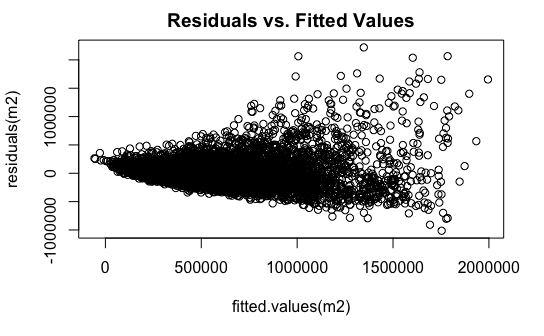

```r
plot(residuals(m2) ~ fitted.values(m2), main="Residuals vs. Fitted Values")
```

This plot displays that our model has incredibly varied variance. This is bad. Let’s build another model, model 3, in which we transform our price to diminish the residual standard errors.

```r
ln_price = log(price)
m3 = lm(ln_price ~ cat_grade + cat_cond + cat_floors + bathrooms +
    ln_sqft_living + ln_sqft15_lot + ln_sqft_above + yr_built +
    zipcode + lat + long + ln_sqft15_living + ln_sqft15_lot +
    ln_bedroom + ln_sqft_basement + basementSq + sqft_livingSq, subset = -lev_points)
summary(m3)
```

```
Call:
lm(formula = ln_price ~ cat_grade + cat_cond + cat_floors + bathrooms +
    ln_sqft_living + ln_sqft15_lot + ln_sqft_above + yr_built +
    zipcode + lat + long + ln_sqft15_living + ln_sqft15_lot +
    ln_bedroom + ln_sqft_basement + basementSq + sqft_livingSq,
    subset = -lev_points)

Residuals:
     Min       1Q   Median       3Q      Max
-1.38524 -0.16167 -0.00347  0.15402  1.12771

Coefficients:
                   Estimate Std. Error t value Pr(>|t|)
(Intercept)       4.246e+00  4.717e+00   0.900 0.368043
cat_grade6        1.673e-01  9.002e-02   1.858 0.063171 .
cat_grade7        3.399e-01  9.012e-02   3.772 0.000163 ***
cat_grade8        5.033e-01  9.037e-02   5.569 2.60e-08 ***
cat_grade9        6.834e-01  9.067e-02   7.537 5.09e-14 ***
cat_grade10       8.192e-01  9.108e-02   8.995  < 2e-16 ***
cat_grade11       9.606e-01  9.237e-02  10.400  < 2e-16 ***
cat_cond4         5.200e-02  5.289e-03   9.832  < 2e-16 ***
cat_cond5         1.175e-01  8.581e-03  13.689  < 2e-16 ***
cat_floors1.5     4.156e-02  8.547e-03   4.863 1.17e-06 ***
cat_floors2       3.624e-02  7.170e-03   5.054 4.37e-07 ***
cat_floors3       1.261e-01  1.545e-02   8.163 3.55e-16 ***
bathrooms         7.462e-02  5.162e-03  14.455  < 2e-16 ***
ln_sqft_living   -2.088e+00  1.918e-01 -10.888  < 2e-16 ***
ln_sqft15_lot    -2.335e-02  3.403e-03  -6.860 7.15e-12 ***
ln_sqft_above     1.102e-01  3.757e-02   2.932 0.003369 **
yr_built         -4.105e-03  1.189e-04 -34.535  < 2e-16 ***
zipcode          -5.725e-04  5.075e-05 -11.282  < 2e-16 ***
lat               1.308e+00  1.651e-02  79.213  < 2e-16 ***
long             -1.213e-01  2.098e-02  -5.781 7.58e-09 ***
ln_sqft15_living  2.310e-01  1.097e-02  21.050  < 2e-16 ***
ln_bedroom       -1.614e-01  1.400e-02 -11.524  < 2e-16 ***
ln_sqft_basement  3.865e-02  8.883e-03   4.351 1.37e-05 ***
basementSq       -4.282e-03  1.618e-03  -2.647 0.008133 **
sqft_livingSq     1.575e-01  1.359e-02  11.585  < 2e-16 ***
---
Signif. codes:  0 ‘***’ 0.001 ‘**’ 0.01 ‘*’ 0.05 ‘.’ 0.1 ‘ ’ 1

Residual standard error: 0.2535 on 14561 degrees of freedom
Multiple R-squared:  0.7471,    Adjusted R-squared:  0.7467
F-statistic:  1792 on 24 and 14561 DF,  p-value: < 2.2e-16
```

Booyah! Model 3 by far has the lowest residual standard error of any of the other models at 0.2535. Also, the R2 value=0.7471 and the R2a=0.7467 has greatly improved compared to the other models. We will now deem this as our current “final” model.

Let’s re-plot to see if we have homoscedasticity

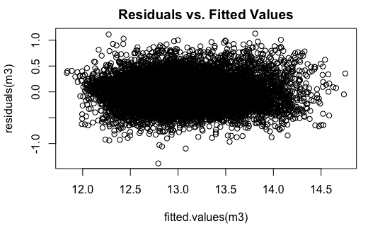

```r
plot(residuals(m3) ~ fitted.values(m3), main="Residuals vs. Fitted Values")
```

That is much better compared to model 2! Let’s see if extracting AIC values will agree with our model selection

```r
extractAIC(m1)
```

```
[1]     33.0 370245.3
```

```r
extractAIC(m2)
```

```
[1]     25 354198
```

```r
extractAIC(m3)
```

```
[1]     25.00 -40013.93
```

Model 3 is significantly better than m3. Let’s continue rolling with this!

## Analysis On Model 3

Let’s do backwards regression to see if we can find a better model from m3

```r
step(m3, data=train_house_data, subset=-lev_points, direction = "backward")
```

```
Start:  AIC=-40013.93
ln_price ~ cat_grade + cat_cond + cat_floors + bathrooms + ln_sqft_living +
    ln_sqft15_lot + ln_sqft_above + yr_built + zipcode + lat +
    long + ln_sqft15_living + ln_sqft15_lot + ln_bedroom + ln_sqft_basement +
    basementSq + sqft_livingSq

                   Df Sum of Sq     RSS    AIC
<none>                           935.50 -40014
- basementSq        1      0.45  935.95 -40009
- ln_sqft_above     1      0.55  936.05 -40007
- ln_sqft_basement  1      1.22  936.71 -39997
- long              1      2.15  937.64 -39982
- ln_sqft15_lot     1      3.02  938.52 -39969
- cat_floors        3      5.49  940.98 -39935
- ln_sqft_living    1      7.62  943.11 -39898
- zipcode           1      8.18  943.68 -39889
- ln_bedroom        1      8.53  944.03 -39884
- sqft_livingSq     1      8.62  944.12 -39882
- bathrooms         1     13.42  948.92 -39808
- cat_cond          2     14.61  950.10 -39792
- ln_sqft15_living  1     28.47  963.96 -39579
- yr_built          1     76.63 1012.12 -38868
- cat_grade         6    147.93 1083.43 -37885
- lat               1    403.13 1338.63 -34789

Call:
lm(formula = ln_price ~ cat_grade + cat_cond + cat_floors + bathrooms +
    ln_sqft_living + ln_sqft15_lot + ln_sqft_above + yr_built +
    zipcode + lat + long + ln_sqft15_living + ln_sqft15_lot +
    ln_bedroom + ln_sqft_basement + basementSq + sqft_livingSq,
    subset = -lev_points)

Coefficients:
     (Intercept)        cat_grade6        cat_grade7        cat_grade8        cat_grade9       cat_grade10       cat_grade11         cat_cond4         cat_cond5
       4.2463282         0.1672742         0.3399081         0.5033175         0.6833538         0.8192183         0.9606272         0.0520015         0.1174568
   cat_floors1.5       cat_floors2       cat_floors3         bathrooms    ln_sqft_living     ln_sqft15_lot     ln_sqft_above          yr_built           zipcode
       0.0415624         0.0362386         0.1260839         0.0746207        -2.0884395        -0.0233491         0.1101831        -0.0041047        -0.0005725
             lat              long  ln_sqft15_living        ln_bedroom  ln_sqft_basement        basementSq     sqft_livingSq
       1.3077863        -0.1212724         0.2310046        -0.1613592         0.0386478        -0.0042817         0.1574770
```

Based on feature engineering, let’s remove some of the sqft terms and see what happens. First we will compute vif (variance inflation factors). Based on the F p-value and the explanatory variables t p-values, we do not suspect collinearity. However, there are lots of terms that are similar that I would like to see if we can get rid of (for example the square feet variables)

#### Variance Inflation Factors

```r
library(Rcmdr)
vif(m3)
```

```
                        GVIF Df GVIF^(1/(2*Df))
cat_grade           4.955828  6        1.142685
cat_cond            1.320442  2        1.071963
cat_floors          4.072576  3        1.263703
bathrooms           3.320578  1        1.822245
ln_sqft_living   1383.824140  1       37.199787
ln_sqft15_lot       1.726189  1        1.313845
ln_sqft_above      54.561570  1        7.386580
yr_built            2.692704  1        1.640946
zipcode             1.675613  1        1.294455
lat                 1.202009  1        1.096362
long                1.937453  1        1.391924
ln_sqft15_living    2.844880  1        1.686677
ln_bedroom          1.869034  1        1.367126
ln_sqft_basement  180.491596  1       13.434716
basementSq        262.635051  1       16.206019
sqft_livingSq    1583.718304  1       39.795958
```

```r
m4 = lm(ln_price ~ cat_grade + cat_cond + cat_floors + bathrooms +
    ln_sqft_living + ln_sqft15_lot + ln_sqft_above + yr_built +
    zipcode + lat + long  + ln_sqft15_lot +
    ln_bedroom,
    subset = -lev_points)
summary(m4)
```

```
Call:
lm(formula = ln_price ~ cat_grade + cat_cond + cat_floors + bathrooms +
    ln_sqft_living + ln_sqft15_lot + ln_sqft_above + yr_built +
    zipcode + lat + long + ln_sqft15_lot + ln_bedroom, subset = -lev_points)

Residuals:
     Min       1Q   Median       3Q      Max
-1.30189 -0.16369 -0.00518  0.15518  1.18977

Coefficients:
                 Estimate Std. Error t value Pr(>|t|)
(Intercept)     2.1964450  4.6561211   0.472 0.637125
cat_grade6      0.1254809  0.0920450   1.363 0.172823
cat_grade7      0.2874687  0.0920041   3.125 0.001784 **
cat_grade8      0.4785436  0.0922400   5.188 2.15e-07 ***
cat_grade9      0.7038185  0.0926154   7.599 3.16e-14 ***
cat_grade10     0.8848906  0.0930990   9.505  < 2e-16 ***
cat_grade11     1.0891373  0.0943707  11.541  < 2e-16 ***
cat_cond4       0.0485027  0.0054080   8.969  < 2e-16 ***
cat_cond5       0.1051255  0.0087569  12.005  < 2e-16 ***
cat_floors1.5   0.0253916  0.0086716   2.928 0.003415 **
cat_floors2     0.0328272  0.0072559   4.524 6.11e-06 ***
cat_floors3     0.0804827  0.0157020   5.126 3.00e-07 ***
bathrooms       0.0850908  0.0051997  16.365  < 2e-16 ***
ln_sqft_living  0.4509102  0.0139179  32.398  < 2e-16 ***
ln_sqft15_lot  -0.0129704  0.0034364  -3.774 0.000161 ***
ln_sqft_above   0.0139719  0.0133822   1.044 0.296471
yr_built       -0.0042888  0.0001212 -35.399  < 2e-16 ***
zipcode        -0.0006274  0.0000517 -12.135  < 2e-16 ***
lat             1.3473624  0.0168172  80.118  < 2e-16 ***
long           -0.1063691  0.0213026  -4.993 6.01e-07 ***
ln_bedroom     -0.1905024  0.0142709 -13.349  < 2e-16 ***
---
Signif. codes:  0 ‘***’ 0.001 ‘**’ 0.01 ‘*’ 0.05 ‘.’ 0.1 ‘ ’ 1

Residual standard error: 0.2594 on 14565 degrees of freedom
Multiple R-squared:  0.735, Adjusted R-squared:  0.7347
F-statistic:  2020 on 20 and 14565 DF,  p-value: < 2.2e-16
```

```r
summary(m3)
```

```
Call:
lm(formula = ln_price ~ cat_grade + cat_cond + cat_floors + bathrooms +
    ln_sqft_living + ln_sqft15_lot + ln_sqft_above + yr_built +
    zipcode + lat + long + ln_sqft15_living + ln_sqft15_lot +
    ln_bedroom + ln_sqft_basement + basementSq + sqft_livingSq,
    subset = -lev_points)

Residuals:
     Min       1Q   Median       3Q      Max
-1.38524 -0.16167 -0.00347  0.15402  1.12771

Coefficients:
                   Estimate Std. Error t value Pr(>|t|)
(Intercept)       4.246e+00  4.717e+00   0.900 0.368043
cat_grade6        1.673e-01  9.002e-02   1.858 0.063171 .
cat_grade7        3.399e-01  9.012e-02   3.772 0.000163 ***
cat_grade8        5.033e-01  9.037e-02   5.569 2.60e-08 ***
cat_grade9        6.834e-01  9.067e-02   7.537 5.09e-14 ***
cat_grade10       8.192e-01  9.108e-02   8.995  < 2e-16 ***
cat_grade11       9.606e-01  9.237e-02  10.400  < 2e-16 ***
cat_cond4         5.200e-02  5.289e-03   9.832  < 2e-16 ***
cat_cond5         1.175e-01  8.581e-03  13.689  < 2e-16 ***
cat_floors1.5     4.156e-02  8.547e-03   4.863 1.17e-06 ***
cat_floors2       3.624e-02  7.170e-03   5.054 4.37e-07 ***
cat_floors3       1.261e-01  1.545e-02   8.163 3.55e-16 ***
bathrooms         7.462e-02  5.162e-03  14.455  < 2e-16 ***
ln_sqft_living   -2.088e+00  1.918e-01 -10.888  < 2e-16 ***
ln_sqft15_lot    -2.335e-02  3.403e-03  -6.860 7.15e-12 ***
ln_sqft_above     1.102e-01  3.757e-02   2.932 0.003369 **
yr_built         -4.105e-03  1.189e-04 -34.535  < 2e-16 ***
zipcode          -5.725e-04  5.075e-05 -11.282  < 2e-16 ***
lat               1.308e+00  1.651e-02  79.213  < 2e-16 ***
long             -1.213e-01  2.098e-02  -5.781 7.58e-09 ***
ln_sqft15_living  2.310e-01  1.097e-02  21.050  < 2e-16 ***
ln_bedroom       -1.614e-01  1.400e-02 -11.524  < 2e-16 ***
ln_sqft_basement  3.865e-02  8.883e-03   4.351 1.37e-05 ***
basementSq       -4.282e-03  1.618e-03  -2.647 0.008133 **
sqft_livingSq     1.575e-01  1.359e-02  11.585  < 2e-16 ***
---
Signif. codes:  0 ‘***’ 0.001 ‘**’ 0.01 ‘*’ 0.05 ‘.’ 0.1 ‘ ’ 1

Residual standard error: 0.2535 on 14561 degrees of freedom
Multiple R-squared:  0.7471,    Adjusted R-squared:  0.7467
F-statistic:  1792 on 24 and 14561 DF,  p-value: < 2.2e-16
```

Although there is a very slight increase in the standard error, decrease in R2 and R2a in model 4, we still have a very significant model. Because of this we will use model 4 as our final model.

```r
extractAIC(m1)
```

```
[1]     33.0 370245.3
```

```r
extractAIC(m2)
```

```
[1]     25 354198
```

```r
extractAIC(m3)
```

```
[1]     25.00 -40013.93
```

```r
extractAIC(m4)
```

```
[1]     21.00 -39344.69
```

## Final Analysis

We now have an excellent model in model4. Let’s see how well the model does against the test dataset.

```r
#detach(train_house_data)
attach(test_house_data)
pred = predict(m4)
temp_ln = sapply(test_house_data$price,log)
actual_preds = data.frame(cbind(actual=temp_ln, predictions=pred))
```

```
number of rows of result is not a multiple of vector length (arg 1)
```

```r
min_max_accuracy = mean(apply(actual_preds, 1, min) / apply(actual_preds, 1, max))
min_max_accuracy
```

```
[1] 0.9604151
```

```r
mape = mean(abs((actual_preds$predictions - actual_preds$actual))/actual_preds$actual)
mape
```

```
[1] 0.04091274
```

If you would like go get the price of a home back into a normal scale, do an exp transformation to cancel out the natural log. For example:

```r
example = predict(m4)[2]
# example is in the natural log scale
example
```

```
       2
13.89521
```

```r
# now we exponentiate it to get it back to the real scale
exp(example)
```

```
      2
1082961
```

# Conclusion

Data Science rules!

Until next time,

Joel Afriyie